# Visualization & Predictive Analysis

# Loading Data & Packages

```r
options(scipen = 999)

library(tidyverse)
library(cluster)
library(factoextra)
library(caret)
library(rpart)
library(rpart.plot)
library(tidymodels)
library(DT)
library(rattle)
library(scales)
library(lemon)
library(plotly)
library(lubridate)
library(ggplot2)

myData <- read.csv('database.csv')

view(myData)
```

# Part One - Data Exploration

## Visual 1

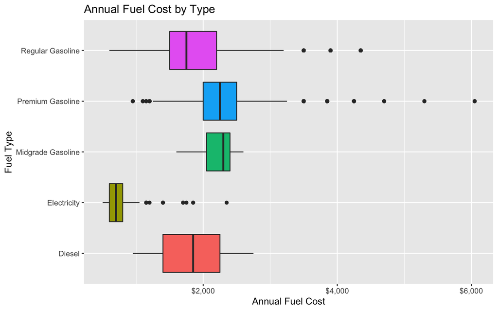

```r
myData %>%
  filter(Fuel.Type.1 != 'Natural Gas') %>%
  ggplot() +
  geom_boxplot(show.legend = F) +
  aes(x = Fuel.Type.1, y = Annual.Fuel.Cost..FT1., fill = Fuel.Type.1) +
  scale_y_continuous(labels = dollar_format()) +
  labs(x = "Fuel Type", y = "Annual Fuel Cost",title = "Annual Fuel Cost by Type") +
  coord_flip()
```

```r
  #shows the $ amount for each fuel type group
```

**This box plot visualizes the differences in yearly fuel costs for the different gas types. It shows how much money Electric cars save, over a $1,000, versus gasoline cars yearly. Also from the data, annual fuel costs for Premium Gasoline is the highest and has the most variance.**

## Visual 2

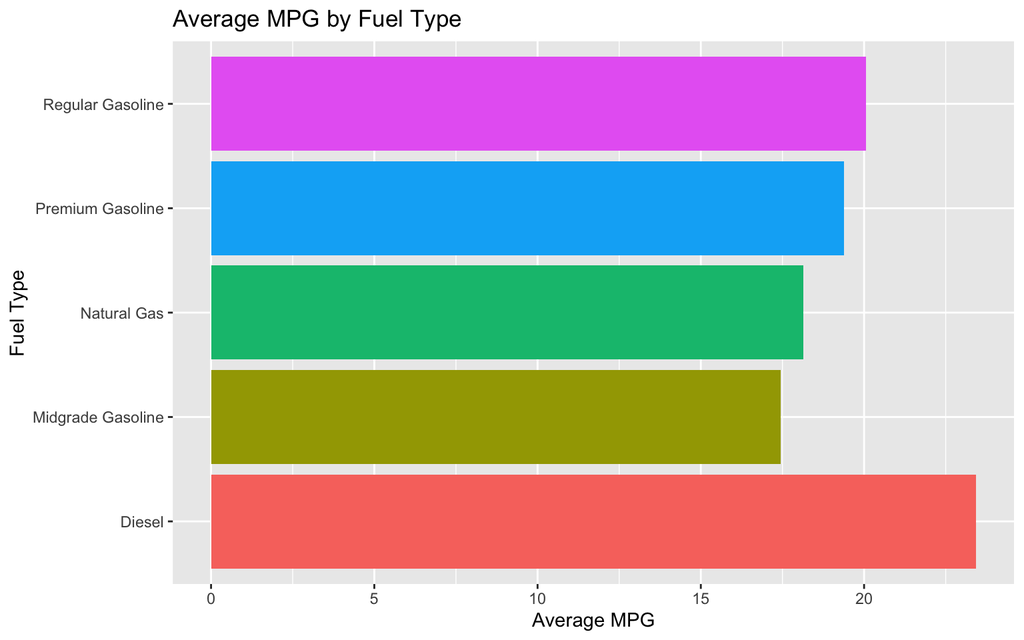

```r
myData %>%
  group_by(Fuel.Type.1) %>%
  filter(Fuel.Type.1 != 'Electricity')%>%
  summarise(averageMPG = mean(Combined.MPG..FT1.)) %>% #calculating avg MPG per Fuel Type
  ggplot() +
  aes(x = averageMPG, y= Fuel.Type.1 , fill = Fuel.Type.1) +
  geom_col(show.legend = F) +
  labs(x = "Average MPG", y = "Fuel Type", title = "Average MPG by Fuel Type")
```

**Now I am comparing the average miles per gallon for cars of each fuel type. According to the visual, Diesel gasoline has the best fuel efficiency.**

## Visual 3

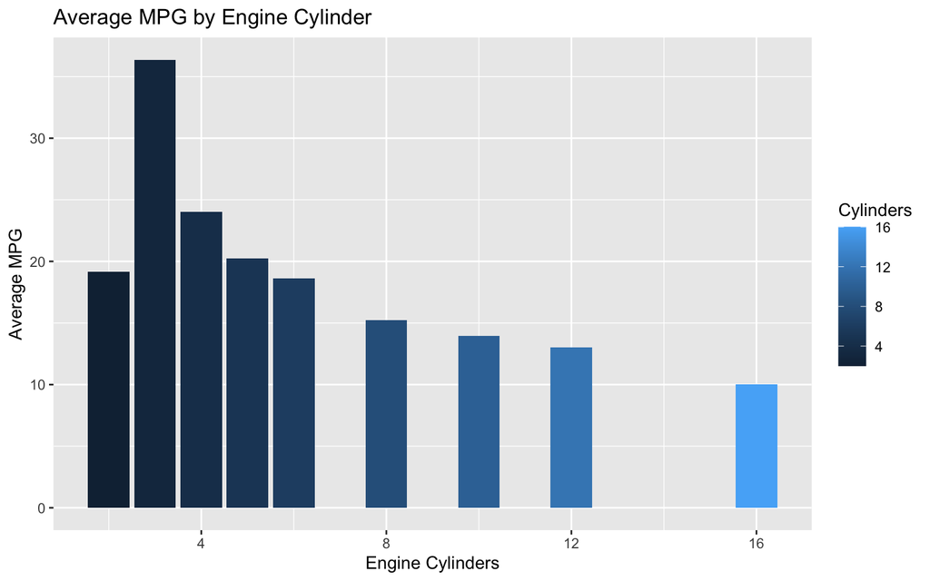

```r
myData %>%
  group_by(Engine.Cylinders) %>%
  summarise(averageMPG = mean(Combined.MPG..FT1.)) %>%
  ggplot(aes(x = Engine.Cylinders, y = averageMPG, fill = Engine.Cylinders))+
  geom_col() +
  labs(title = "Average MPG by Engine Cylinder", y = "Average MPG", x = "Engine Cylinders", fill = "Cylinders")
```

```r
  #shows MPG average grouped by cylinders
```

**The bar graph visualizes the average combined MPG grouped by the vehicles’ engine size. This identifies that the less cylinders, the smaller the engine; therefore, the vehicle will have a greater MPG. According to the data, 4 cylinder cars average almost 10 more miles per gallon than v8s.**

## Visual 4

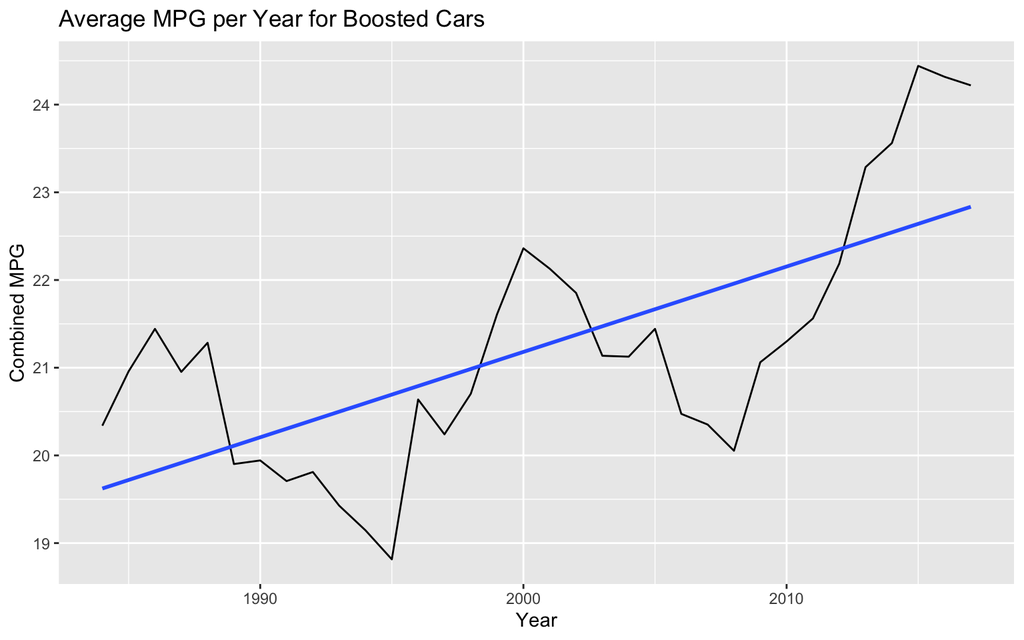

```r
boostedVehicles <- myData %>%
  mutate(noTurbo = is.na(Turbocharger)) %>%
  mutate(noSuperCharger = ifelse(Supercharger == 'S', FALSE, TRUE)) %>%
  mutate(hasBoost = (ifelse(noTurbo== FALSE | noSuperCharger == FALSE , 'BOOST!', 'No Boost'))) %>%
  filter(hasBoost == 'BOOST!')
#getting only vehicles with boost

boostedVehicles %>%
  group_by(Year) %>%
  summarise(avergaeCombinedMPG = mean((City.MPG..FT1. + Highway.MPG..FT1.)/2)) %>%
  ggplot(aes(x = Year, y = avergaeCombinedMPG))+
  geom_line()+
  geom_smooth(method = 'lm', se = FALSE) +
  labs(title = 'Average MPG per Year for Boosted Cars', y = 'Combined MPG', x = 'Year')
```

```r
  #seeing MPG vs Time for boosted cars
```

## Visual 5

```r
myData.features <- myData%>%
  select(City.MPG..FT1., Highway.MPG..FT1., Unadjusted.Highway.MPG..FT1. , Unadjusted.City.MPG..FT1. )


myClusters <- kmeans(myData.features,3)


# Viewing Clusters
table(myData$Class, myClusters$cluster)
```

```
##
##                                         1    2    3
##   Compact Cars                          8 1649 3851
##   Large Cars                           32 1326  533
##   Midsize Cars                         13 2184 2198
##   Midsize Station Wagons                1  305  217
##   Midsize-Large Station Wagons          0  441  215
##   Minicompact Cars                      7  699  554
##   Minivan - 2WD                         0  303   39
##   Minivan - 4WD                         0   47    0
##   Small Pickup Trucks                   0  386  152
##   Small Pickup Trucks 2WD               0  319  117
##   Small Pickup Trucks 4WD               0  208   10
##   Small Sport Utility Vehicle 2WD       5   61  337
##   Small Sport Utility Vehicle 4WD       0  180  346
##   Small Station Wagons                  6  344 1149
##   Special Purpose Vehicle               0    0    1
##   Special Purpose Vehicle 2WD           2  513   98
##   Special Purpose Vehicle 4WD           0  293    9
##   Special Purpose Vehicles              0 1316  139
##   Special Purpose Vehicles/2wd          0    2    0
##   Special Purpose Vehicles/4wd          0    2    0
##   Sport Utility Vehicle - 2WD           6 1228  393
##   Sport Utility Vehicle - 4WD           0 1865  217
##   Standard Pickup Trucks                0 2327   27
##   Standard Pickup Trucks 2WD            0 1138   39
##   Standard Pickup Trucks 4WD            0  985    1
##   Standard Pickup Trucks/2wd            0    4    0
##   Standard Sport Utility Vehicle 2WD    0  162   20
##   Standard Sport Utility Vehicle 4WD   10  366   58
##   Subcompact Cars                      16 1938 2918
##   Two Seaters                          13 1195  678
##   Vans                                  0 1128   13
##   Vans Passenger                        0    2    0
##   Vans, Cargo Type                      0  437    1
##   Vans, Passenger Type                  0  311    0
```

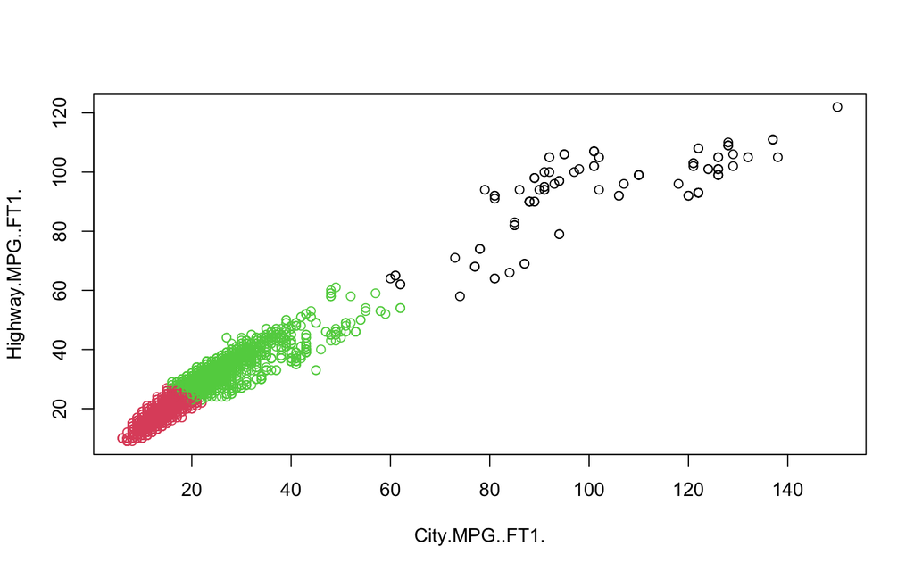

```r
#Plot our results to see what we get
plot(myData[c("City.MPG..FT1.","Highway.MPG..FT1.")], col = myClusters$cluster)
```

**After performing the K-means algorithm on the City and Highway MPG, I found that there are 3 optimal clusters to this data. I ran the algorithm with 2 and 4 clusters and found too many data points were being held in 2 clusters, and too little data points were found with 4 clusters. The most data points were Compact Cars, Midsize Cars, and Subcompact Cars because these are the most common type of vehicles.**